# 02 — Descriptive Analysis: Pre- and Post-COVID

DS 340W Research Team

# 1 Pre-COVID and Post-COVID Exploratory Data Analysis

# 2 Setup

## 2.1 Plot Colors and Theme

```r
# Define consistent colors and identify the variables used throughout the comparisons.
pre_color <- "#377EB8"
post_color <- "#E69F00"

phq_color <- "#377EB8"
gad_color <- "#E69F00"

gender_colors <- c(
  "Men" = "#377EB8",
  "Women" = "#E69F00"
)

period_colors <- c(
  "2017-2018 Pre-COVID" = "#377EB8",
  "2022-2023 Post-COVID" = "#E69F00"
)

measure_colors <- c(
  "PHQ" = "#377EB8",
  "GAD" = "#E69F00"
)

theme_set(
  theme_minimal(base_size = 12) +
    theme(
      plot.title = element_text(face = "bold"),
      axis.text.x = element_text(
        angle = 0,
        hjust = 0.5
      ),
      legend.position = "bottom",
      panel.grid.minor = element_blank()
    )
)
```

# 3 Load Data

```r
# Load the cleaned pre-COVID and post-COVID datasets from the project folders.
project_root <- here::here()

pre_path <- file.path(project_root, "data", "processed", "pre_covid_clean.csv")
post_path <- file.path(project_root, "data", "processed", "post_covid_clean.csv")

# Confirm the project root and both input files.
if (!file.exists(pre_path) || !file.exists(post_path)) {
  stop(
    "Missing processed data files. Open the project's .Rproj file first. ",
    "Project root: ", project_root, ". ",
    "Expected: data/processed/pre_covid_clean.csv and ",
    "data/processed/post_covid_clean.csv"
  )
}

pre_covid <- readr::read_csv(pre_path, show_col_types = FALSE)
post_covid <- readr::read_csv(post_path, show_col_types = FALSE)

# Confirm the variables used throughout the descriptive analysis.
variables_used <- c(
  "PHQ", "GAD", "gender", "field", "race.2", "yr_sch.2", "fincur.2", "age"
)

for (period_name in c("pre_covid", "post_covid")) {
  missing_columns <- setdiff(variables_used, names(get(period_name)))
  if (length(missing_columns) > 0) {
    stop(period_name, " is missing: ", paste(missing_columns, collapse = ", "))
  }
}
```

# 4 Make Variables Consistent

```r
# Standardize the post-COVID variable categories so they can be compared with the pre-COVID data.
post_covid <- post_covid %>%
  mutate(
    field = case_when(
      as.character(field) == "STEM" ~ "STEM",
      as.character(field) %in% c("NotSTEM", "Non-STEM") ~ "Non-STEM",
      TRUE ~ as.character(field)
    ),
    gender = as.character(gender),
    field = as.character(field),
    race.2 = as.character(race.2),
    yr_sch.2 = as.character(yr_sch.2),
    fincur.2 = as.numeric(fincur.2),
    age = as.numeric(age)
  )

pre_covid <- pre_covid %>%
  mutate(
    gender = as.character(gender),
    field = as.character(field),
    race.2 = as.character(race.2),
    yr_sch.2 = as.character(yr_sch.2),
    fincur.2 = as.numeric(fincur.2),
    age = as.numeric(age)
  )

pre_covid$gender <- factor(
  pre_covid$gender,
  levels = c("Men", "Women")
)

post_covid$gender <- factor(
  post_covid$gender,
  levels = c("Men", "Women")
)

pre_covid$field <- factor(
  pre_covid$field,
  levels = c("Non-STEM", "STEM")
)

post_covid$field <- factor(
  post_covid$field,
  levels = c("Non-STEM", "STEM")
)

race_levels <- c(
  "White",
  "Asian",
  "Black",
  "Hispanic",
  "Middle Eastern"
)

pre_covid$race.2 <- factor(
  pre_covid$race.2,
  levels = race_levels
)

post_covid$race.2 <- factor(
  post_covid$race.2,
  levels = race_levels
)

year_levels <- c(
  "firstyear",
  "secondyear",
  "thirdyear",
  "fourthyear+"
)

pre_covid$yr_sch.2 <- factor(
  pre_covid$yr_sch.2,
  levels = year_levels
)

post_covid$yr_sch.2 <- factor(
  post_covid$yr_sch.2,
  levels = year_levels
)
```

# 5 Final Data Check

```r
# Check the number of observations and variables in the pre-COVID dataset.
dim(pre_covid)
```

```
## [1] 68427    29
```

```r
# Check the number of observations and variables in the post-COVID dataset.
dim(post_covid)
```

```
## [1] 43910    31
```

```r
# Confirm that the variables needed for descriptive analysis exist in both datasets.
# Verify that both datasets contain the analysis variables.
variable_check <- data.frame(
  Variable = variables_used,
  Pre_COVID = variables_used %in% names(pre_covid),
  Post_COVID = variables_used %in% names(post_covid)
)

knitr::kable(
  variable_check,
  caption = "Variables Available in Both Datasets"
)
```

Variables Available in Both Datasets

| Variable | Pre_COVID | Post_COVID |
| --- | --- | --- |
| PHQ | TRUE | TRUE |
| GAD | TRUE | TRUE |
| gender | TRUE | TRUE |
| field | TRUE | TRUE |
| race.2 | TRUE | TRUE |
| yr_sch.2 | TRUE | TRUE |
| fincur.2 | TRUE | TRUE |
| age | TRUE | TRUE |

# 6 2017-2018 Pre-COVID EDA

## 6.1 Dataset Overview

```r
# Report the dimensions of the pre-COVID sample before exploring its characteristics.
dim(pre_covid)
```

```
## [1] 68427    29
```

```r
# Inspect the pre-COVID variable types and a preview of their values.
glimpse(pre_covid)
```

```
## Rows: 68,427
## Columns: 29
## $ responseid   <chr> "R_3fjAY7LPxjUR4gM", "R_3gUFAn1X2aRpaTP", "R_2t2Ownvx74…
## $ schoolnum    <dbl> 238, 238, 238, 238, 238, 238, 238, 238, 238, 238, 238, …
## $ age          <dbl> 18, 26, 28, 22, 26, 49, 35, 36, 29, 25, 34, 24, 44, 35,…
## $ gender       <fct> Women, Men, Men, Women, NA, Women, Men, Women, Women, W…
## $ field        <fct> Non-STEM, Non-STEM, Non-STEM, Non-STEM, Non-STEM, Non-S…
## $ gender.field <lgl> NA, NA, NA, NA, NA, NA, NA, NA, NA, NA, NA, NA, NA, NA,…
## $ race.2       <fct> White, White, White, Asian, White, White, NA, White, Wh…
## $ PHQ          <dbl> 1.555556, 1.333333, 1.777778, 1.333333, 2.555556, 1.444…
## $ GAD          <dbl> 1.428571, 1.428571, 1.571429, 1.428571, 2.428571, 2.000…
## $ fincur.2     <dbl> 3, 3, 2, 5, 2, 3, 3, 3, 2, 2, 2, 3, 3, 1, 2, 2, 2, 4, 2…
## $ aca_anx_1    <dbl> NA, NA, NA, NA, NA, NA, NA, NA, NA, NA, NA, NA, NA, NA,…
## $ aca_anx_2    <dbl> NA, NA, NA, NA, NA, 1, 1, NA, NA, NA, NA, NA, 1, 1, NA,…
## $ aca_anx_3    <dbl> NA, 1, 1, NA, 1, NA, NA, NA, 1, 1, NA, 1, NA, NA, NA, N…
```

[output cut: 16 more lines]

## 6.2 Missing Values

```r
# Count missing values for each selected variable in the pre-COVID sample.
pre_missing <- data.frame(
  Variable = variables_used,
  Missing = sapply(
    pre_covid[, variables_used],
    function(x) sum(is.na(x))
  ),
  Percent_Missing = sapply(
    pre_covid[, variables_used],
    function(x) mean(is.na(x)) * 100
  )
)

pre_missing$Percent_Missing <- round(
  pre_missing$Percent_Missing,
  2
)

knitr::kable(
  pre_missing,
  caption = "Missing Data: 2017-2018"
)
```

Missing Data: 2017-2018

|  | Variable | Missing | Percent_Missing |
| --- | --- | --- | --- |
| PHQ | PHQ | 16788 | 24.53 |
| GAD | GAD | 17362 | 25.37 |
| gender | gender | 1876 | 2.74 |
| field | field | 11155 | 16.30 |
| race.2 | race.2 | 8453 | 12.35 |
| yr_sch.2 | yr_sch.2 | 5991 | 8.76 |
| fincur.2 | fincur.2 | 988 | 1.44 |
| age | age | 0 | 0.00 |

## 6.3 Depression and Anxiety Scores

```r
# Summarize the distribution of pre-COVID depression (PHQ) scores.
summary(pre_covid$PHQ)
```

```
##    Min. 1st Qu.  Median    Mean 3rd Qu.    Max.    NA's
##   1.000   1.333   1.778   1.892   2.222   4.000   16788
```

```r
# Summarize the distribution of pre-COVID anxiety (GAD) scores.
summary(pre_covid$GAD)
```

```
##    Min. 1st Qu.  Median    Mean 3rd Qu.    Max.    NA's
##   1.000   1.286   1.857   1.984   2.429   4.000   17362
```

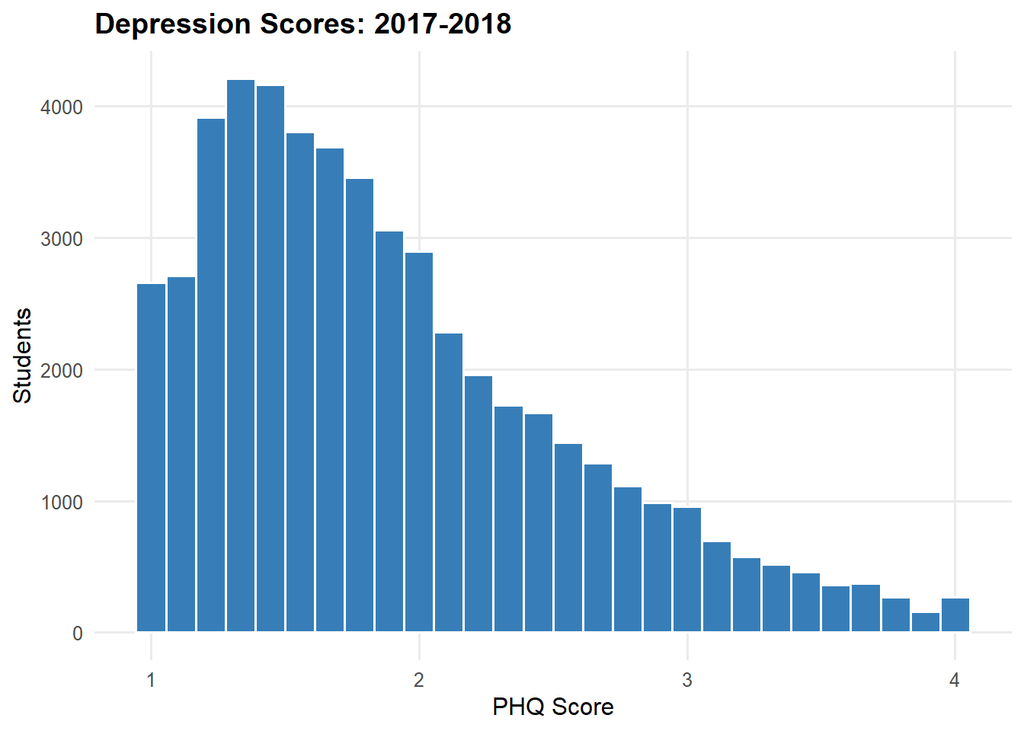

```r
# Plot the distribution of depression scores in the pre-COVID sample.
ggplot(pre_covid, aes(x = PHQ)) +
  geom_histogram(
    binwidth = 1/9,
    fill = phq_color,
    color = "white"
  ) +
  labs(
    title = "Depression Scores: 2017-2018",
    x = "PHQ Score",
    y = "Students"
  )
```

Most students had lower depression scores, with fewer students having scores toward the higher end of the scale.

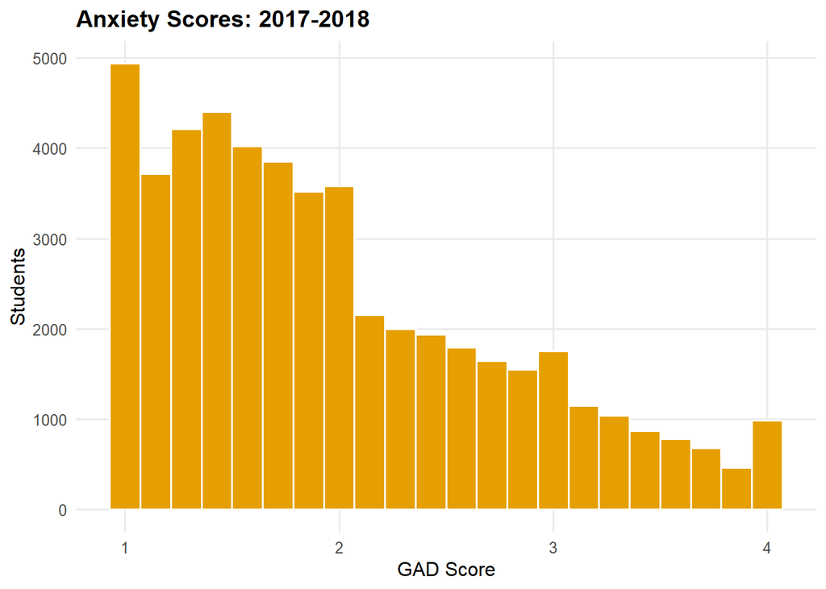

```r
# Plot the distribution of anxiety scores in the pre-COVID sample.
ggplot(pre_covid, aes(x = GAD)) +
  geom_histogram(
    binwidth = 1/7,
    fill = gad_color,
    color = "white"
  ) +
  labs(
    title = "Anxiety Scores: 2017-2018",
    x = "GAD Score",
    y = "Students"
  )
```

Most students had lower anxiety scores, although there were still students with scores across the full range.

## 6.4 Gender Distribution

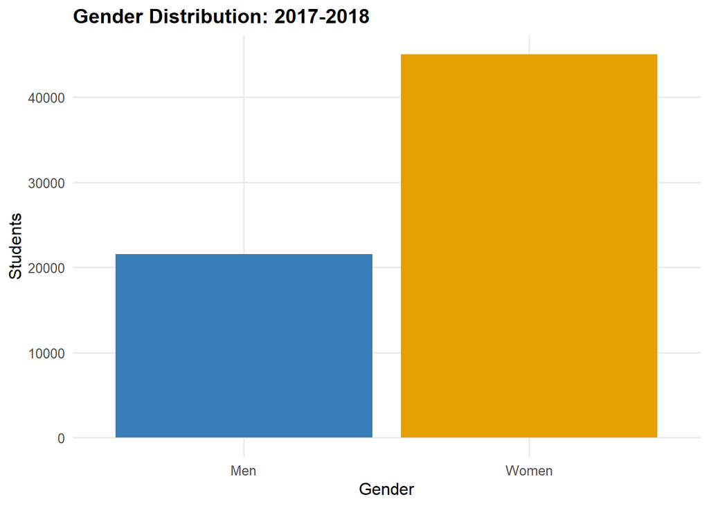

```r
# Show the gender composition of the pre-COVID sample.
ggplot(
  filter(pre_covid, !is.na(gender)),
  aes(x = gender, fill = gender)
) +
  geom_bar() +
  scale_fill_manual(values = gender_colors) +
  guides(fill = "none") +
  labs(
    title = "Gender Distribution: 2017-2018",
    x = "Gender",
    y = "Students"
  )
```

There were more women than men in the pre-COVID sample.

## 6.5 STEM and Non-STEM Distribution

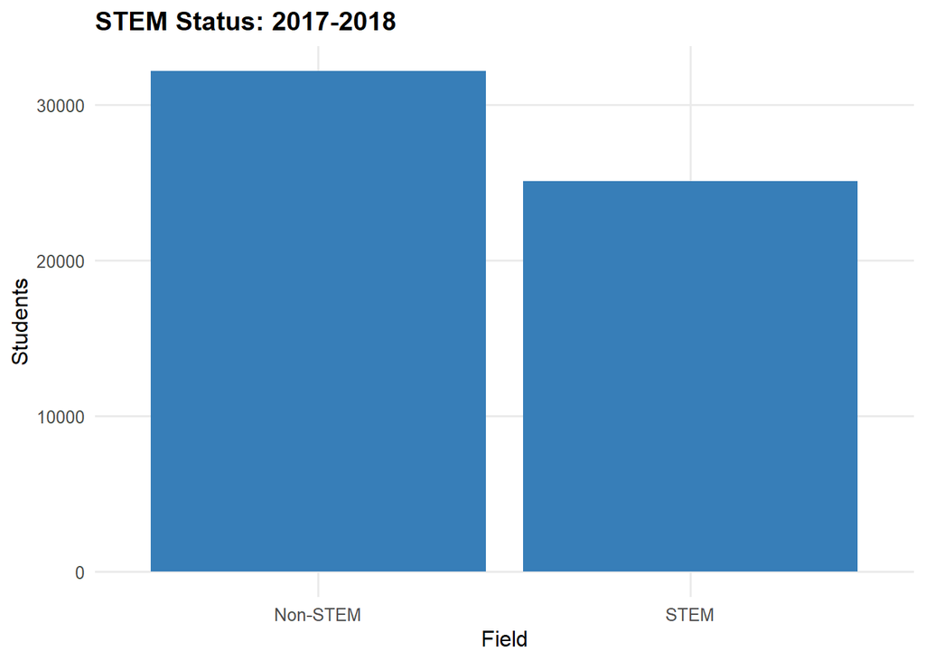

```r
# Show the distribution of STEM and non-STEM fields before COVID-19.
ggplot(
  filter(pre_covid, !is.na(field)),
  aes(x = field)
) +
  geom_bar(fill = pre_color) +
  labs(
    title = "STEM Status: 2017-2018",
    x = "Field",
    y = "Students"
  )
```

The pre-COVID sample included both STEM and non-STEM students, with more students in the non-STEM group.

## 6.6 Race Distribution

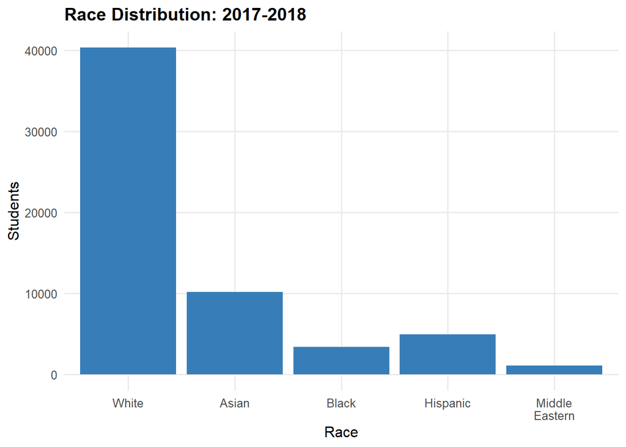

```r
# Describe the racial composition of the pre-COVID sample.
ggplot(
  filter(pre_covid, !is.na(race.2)),
  aes(x = race.2)
) +
  geom_bar(fill = pre_color) +
  labs(
    title = "Race Distribution: 2017-2018",
    x = "Race",
    y = "Students"
  ) +
  scale_x_discrete(
    labels = c(
      "White",
      "Asian",
      "Black",
      "Hispanic",
      "Middle\nEastern"
    )
  )
```

White students made up the largest racial group in the pre-COVID sample.

## 6.7 Year in School Distribution

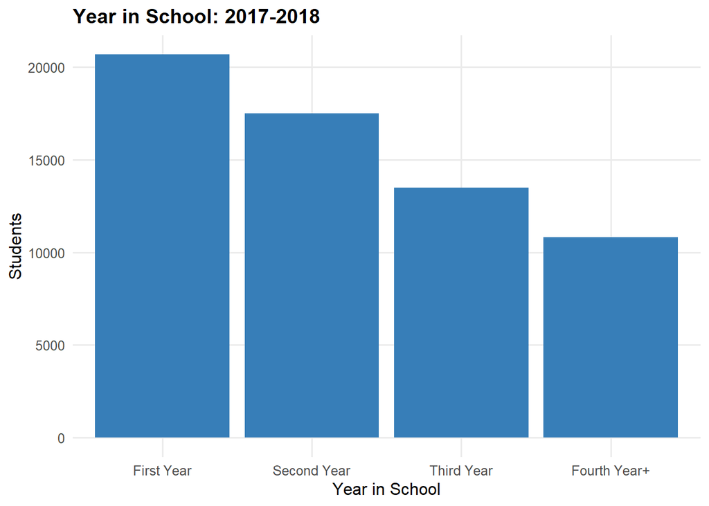

```r
# Show the distribution of students by year in school before COVID-19.
ggplot(
  filter(pre_covid, !is.na(yr_sch.2)),
  aes(x = yr_sch.2)
) +
  geom_bar(fill = pre_color) +
  scale_x_discrete(
    labels = c(
      "First Year",
      "Second Year",
      "Third Year",
      "Fourth Year+"
    )
  ) +
  labs(
    title = "Year in School: 2017-2018",
    x = "Year in School",
    y = "Students"
  )
```

Students from all years in school were represented in the pre-COVID sample.

## 6.8 Financial Stress Distribution

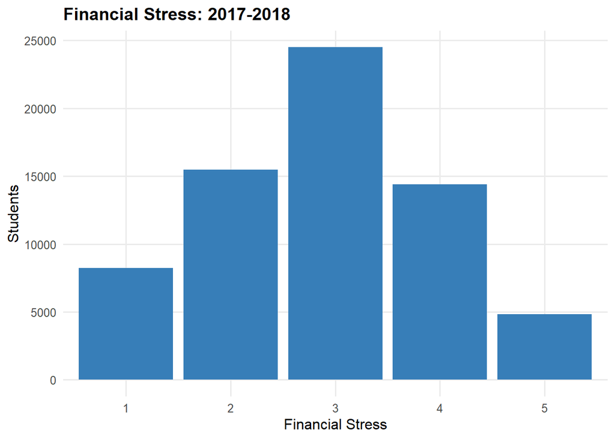

```r
# Describe current financial circumstances among pre-COVID respondents.
ggplot(
  filter(pre_covid, !is.na(fincur.2)),
  aes(x = factor(fincur.2))
) +
  geom_bar(fill = pre_color) +
  labs(
    title = "Financial Stress: 2017-2018",
    x = "Financial Stress",
    y = "Students"
  )
```

Financial stress varied across students, with most students falling around the middle of the scale.

## 6.9 Age Distribution

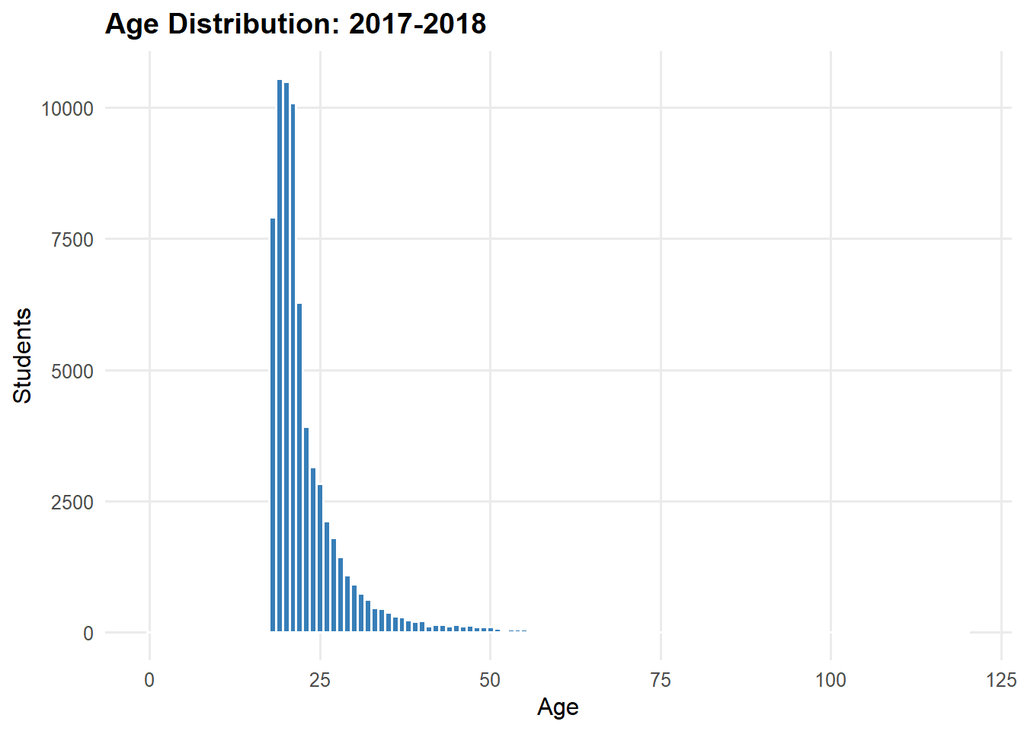

```r
# Plot the age distribution of students in the pre-COVID sample.
ggplot(
  filter(pre_covid, !is.na(age)),
  aes(x = age)
) +
  geom_histogram(
    binwidth = 1,
    fill = pre_color,
    color = "white"
  ) +
  labs(
    title = "Age Distribution: 2017-2018",
    x = "Age",
    y = "Students"
  )
```

Most students were in the typical college-age range, with fewer students at older ages.

## 6.10 Mental Health by Gender

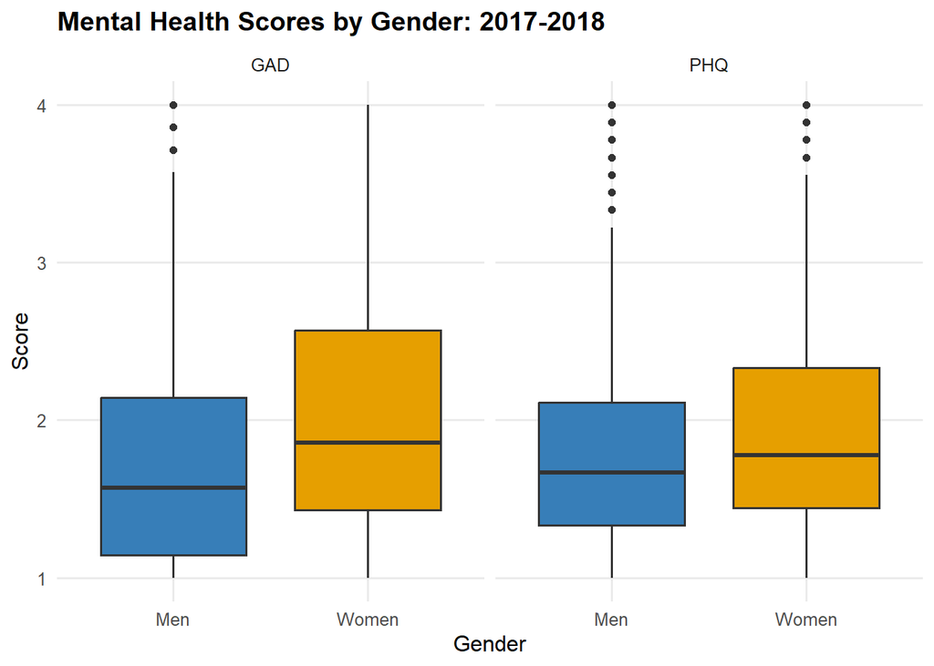

```r
# Compare pre-COVID depression and anxiety scores across gender groups.
pre_gender_scores <- pre_covid %>%
  select(gender, PHQ, GAD) %>%
  pivot_longer(
    c(PHQ, GAD),
    names_to = "Measure",
    values_to = "Score"
  )

ggplot(
  filter(
    pre_gender_scores,
    !is.na(gender),
    !is.na(Score)
  ),
  aes(
    x = gender,
    y = Score,
    fill = gender
  )
) +
  geom_boxplot() +
  facet_wrap(~Measure) +
  scale_fill_manual(values = gender_colors) +
  guides(fill = "none") +
  labs(
    title = "Mental Health Scores by Gender: 2017-2018",
    x = "Gender",
    y = "Score"
  )
```

Women generally had higher depression and anxiety scores than men before COVID.

## 6.11 Mental Health by STEM Status

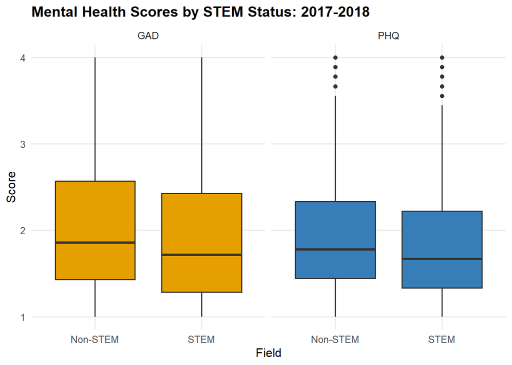

```r
# Compare pre-COVID depression and anxiety scores by STEM field status.
pre_field_scores <- pre_covid %>%
  select(field, PHQ, GAD) %>%
  pivot_longer(
    c(PHQ, GAD),
    names_to = "Measure",
    values_to = "Score"
  )

ggplot(
  filter(
    pre_field_scores,
    !is.na(field),
    !is.na(Score)
  ),
  aes(
    x = field,
    y = Score,
    fill = Measure
  )
) +
  geom_boxplot() +
  facet_wrap(~Measure) +
  scale_fill_manual(values = measure_colors) +
  guides(fill = "none") +
  labs(
    title = "Mental Health Scores by STEM Status: 2017-2018",
    x = "Field",
    y = "Score"
  )
```

The pre-COVID sample included both STEM and non-STEM students, with more students in the non-STEM group.

## 6.12 Mental Health by Financial Stress

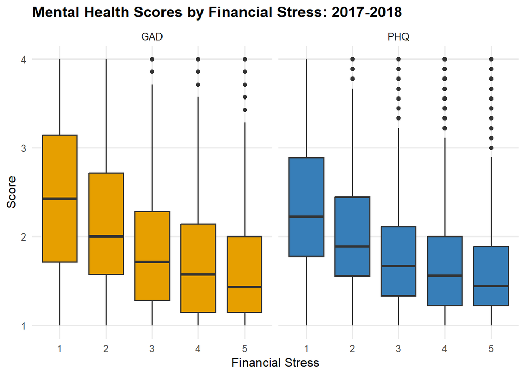

```r
# Examine pre-COVID mental health scores across financial circumstances.
pre_financial_scores <- pre_covid %>%
  select(fincur.2, PHQ, GAD) %>%
  pivot_longer(
    c(PHQ, GAD),
    names_to = "Measure",
    values_to = "Score"
  )

ggplot(
  filter(
    pre_financial_scores,
    !is.na(fincur.2),
    !is.na(Score)
  ),
  aes(
    x = factor(fincur.2),
    y = Score,
    fill = Measure
  )
) +
  geom_boxplot() +
  facet_wrap(~Measure) +
  scale_fill_manual(values = measure_colors) +
  guides(fill = "none") +
  labs(
    title = "Mental Health Scores by Financial Stress: 2017-2018",
    x = "Financial Stress",
    y = "Score"
  )
```

Financial stress varied across students, with most students falling around the middle of the scale.

## 6.13 Mental Health by Race

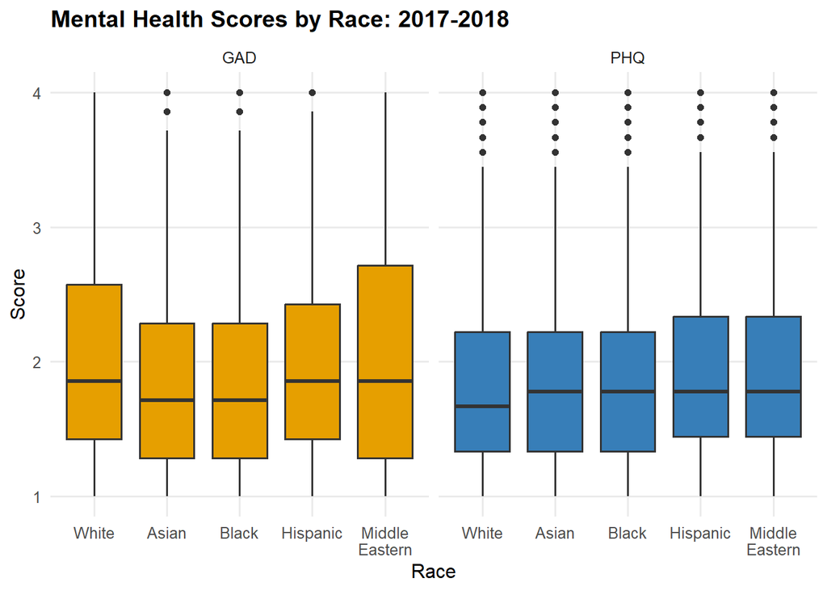

```r
# Compare pre-COVID depression and anxiety scores across racial groups.
pre_race_scores <- pre_covid %>%
  select(race.2, PHQ, GAD) %>%
  pivot_longer(
    c(PHQ, GAD),
    names_to = "Measure",
    values_to = "Score"
  )

ggplot(
  filter(
    pre_race_scores,
    !is.na(race.2),
    !is.na(Score)
  ),
  aes(
    x = race.2,
    y = Score,
    fill = Measure
  )
) +
  geom_boxplot() +
  facet_wrap(~Measure) +
  scale_fill_manual(values = measure_colors) +
  guides(fill = "none") +
  scale_x_discrete(
    labels = c(
      "White",
      "Asian",
      "Black",
      "Hispanic",
      "Middle\nEastern"
    )
  ) +
  labs(
    title = "Mental Health Scores by Race: 2017-2018",
    x = "Race",
    y = "Score"
  )
```

Depression and anxiety scores varied somewhat across racial groups before COVID.

## 6.14 Mental Health by Year in School

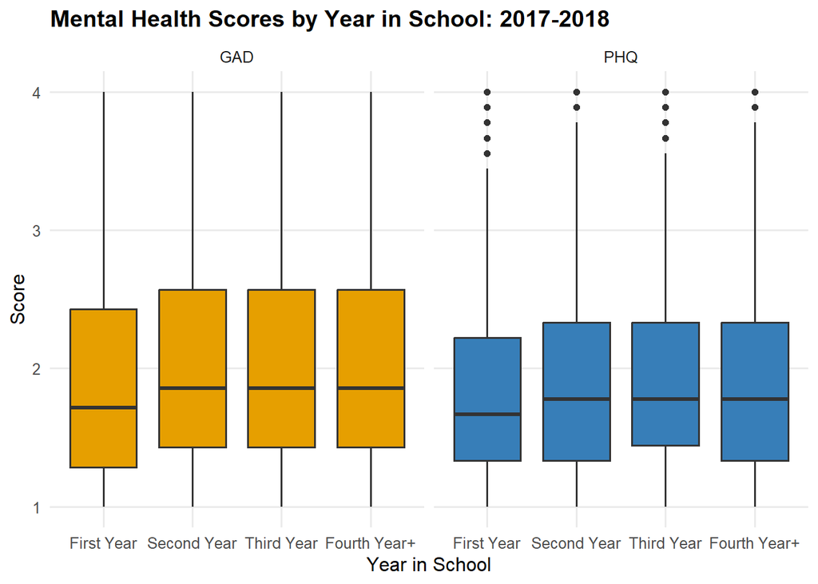

```r
# Compare pre-COVID depression and anxiety scores by year in school.
pre_year_scores <- pre_covid %>%
  select(yr_sch.2, PHQ, GAD) %>%
  pivot_longer(
    c(PHQ, GAD),
    names_to = "Measure",
    values_to = "Score"
  )

ggplot(
  filter(
    pre_year_scores,
    !is.na(yr_sch.2),
    !is.na(Score)
  ),
  aes(
    x = yr_sch.2,
    y = Score,
    fill = Measure
  )
) +
  geom_boxplot() +
  facet_wrap(~Measure) +
  scale_fill_manual(values = measure_colors) +
  guides(fill = "none") +
  scale_x_discrete(
    labels = c(
      "First Year",
      "Second Year",
      "Third Year",
      "Fourth Year+"
    )
  ) +
  labs(
    title = "Mental Health Scores by Year in School: 2017-2018",
    x = "Year in School",
    y = "Score"
  )
```

Students from all years in school were represented in the pre-COVID sample.

## 6.15 Depression and Anxiety Relationship

```r
# Calculate the correlation between pre-COVID depression and anxiety scores.
pre_correlation <- cor(
  pre_covid$PHQ,
  pre_covid$GAD,
  use = "complete.obs"
)

pre_correlation
```

```
## [1] 0.7497138
```

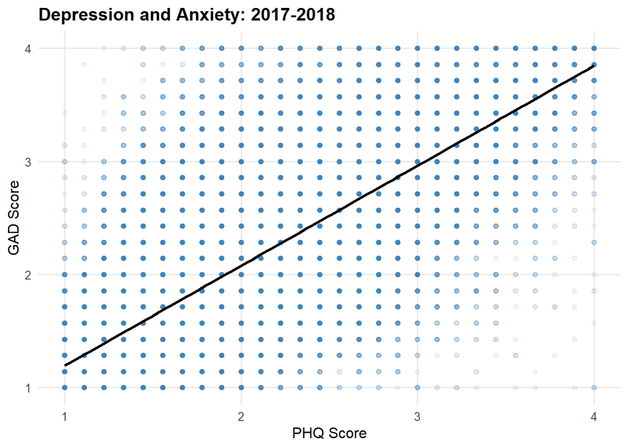

```r
# Visualize the relationship between pre-COVID depression and anxiety scores.
ggplot(
  pre_covid,
  aes(x = PHQ, y = GAD)
) +
  geom_point(
    alpha = 0.08,
    color = pre_color
  ) +
  geom_smooth(
    method = "lm",
    se = FALSE,
    color = "black"
  ) +
  labs(
    title = "Depression and Anxiety: 2017-2018",
    x = "PHQ Score",
    y = "GAD Score"
  )
```

Depression and anxiety had a strong positive relationship, meaning students with higher depression scores also tended to have higher anxiety scores.

# 7 2022-2023 Post-COVID EDA

## 7.1 Dataset Overview

```r
# Check the number of observations and variables in the post-COVID sample.
dim(post_covid)
```

```
## [1] 43910    31
```

```r
# Inspect the post-COVID variable types and a preview of their values.
glimpse(post_covid)
```

```
## Rows: 43,910
## Columns: 31
## $ ...1         <dbl> 1, 2, 3, 4, 5, 6, 7, 8, 9, 10, 11, 12, 13, 14, 15, 16, …
## $ responseid   <chr> "R_305XFCxIAD4Adso", "R_3PzBYXlOn9d51bs", "R_DwRSIFjs6R…
## $ schoolnum    <dbl> 1, 1, 1, 1, 1, 1, 1, 1, 1, 1, 1, 1, 1, 1, 1, 1, 1, 1, 1…
## $ age          <dbl> 21, 21, 27, 19, 21, 22, 43, 18, 53, 21, 37, 19, 19, 18,…
## $ gender       <fct> Women, Men, Women, Women, Women, Women, Women, Women, W…
## $ field        <fct> STEM, NA, STEM, Non-STEM, Non-STEM, STEM, Non-STEM, STE…
## $ gender.field <chr> "WomenSTEM", NA, "WomenSTEM", "WomenNotSTEM", "WomenNot…
## $ race.2       <fct> White, White, Black, White, Hispanic, White, Hispanic, …
## $ orientation  <chr> "Heterosexual", "Heterosexual", "Heterosexual", "Hetero…
## $ PHQ          <dbl> 2.000000, NA, 1.333333, 1.222222, 2.000000, 2.222222, N…
## $ GAD          <dbl> 2.857143, NA, 1.166667, 1.166667, 2.428571, 2.857143, N…
## $ fincur.2     <dbl> 4, 3, 4, 3, 4, 5, 5, 5, 4, 5, 3, 4, 2, 3, 4, 3, 3, 4, 5…
## $ aca_anx_1    <dbl> 0, 0, 0, 0, 0, 0, 0, 0, 0, 0, 0, 0, 0, 0, 0, 0, 0, 0, 0…
```

[output cut: 18 more lines]

## 7.2 Missing Values

```r
# Count missing values for each selected variable in the post-COVID sample.
post_missing <- data.frame(
  Variable = variables_used,
  Missing = sapply(
    post_covid[, variables_used],
    function(x) sum(is.na(x))
  ),
  Percent_Missing = sapply(
    post_covid[, variables_used],
    function(x) mean(is.na(x)) * 100
  )
)

post_missing$Percent_Missing <- round(
  post_missing$Percent_Missing,
  2
)

knitr::kable(
  post_missing,
  caption = "Missing Data: 2022-2023"
)
```

Missing Data: 2022-2023

|  | Variable | Missing | Percent_Missing |
| --- | --- | --- | --- |
| PHQ | PHQ | 2441 | 5.56 |
| GAD | GAD | 2863 | 6.52 |
| gender | gender | 0 | 0.00 |
| field | field | 2888 | 6.58 |
| race.2 | race.2 | 5152 | 11.73 |
| yr_sch.2 | yr_sch.2 | 417 | 0.95 |
| fincur.2 | fincur.2 | 44 | 0.10 |
| age | age | 0 | 0.00 |

## 7.3 Depression and Anxiety Scores

```r
# Summarize the distribution of post-COVID depression (PHQ) scores.
summary(post_covid$PHQ)
```

```
##    Min. 1st Qu.  Median    Mean 3rd Qu.    Max.    NA's
##   1.000   1.444   1.889   1.990   2.444   4.000    2441
```

```r
# Summarize the distribution of post-COVID anxiety (GAD) scores.
summary(post_covid$GAD)
```

```
##    Min. 1st Qu.  Median    Mean 3rd Qu.    Max.    NA's
##   1.000   1.429   2.000   2.155   2.714   4.000    2863
```

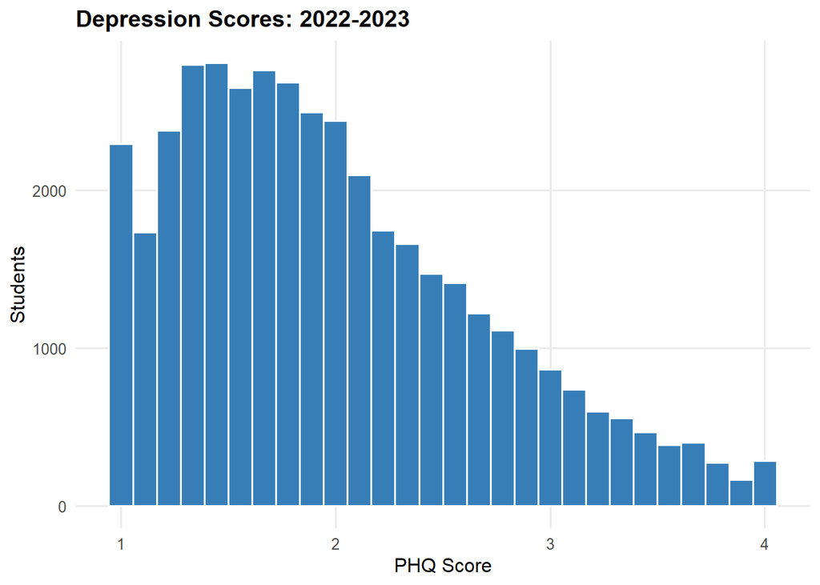

```r
# Plot the distribution of depression scores in the post-COVID sample.
ggplot(post_covid, aes(x = PHQ)) +
  geom_histogram(
    binwidth = 1/9,
    fill = phq_color,
    color = "white"
  ) +
  labs(
    title = "Depression Scores: 2022-2023",
    x = "PHQ Score",
    y = "Students"
  )
```

Most students had lower to moderate depression scores, although scores were spread across the full range.

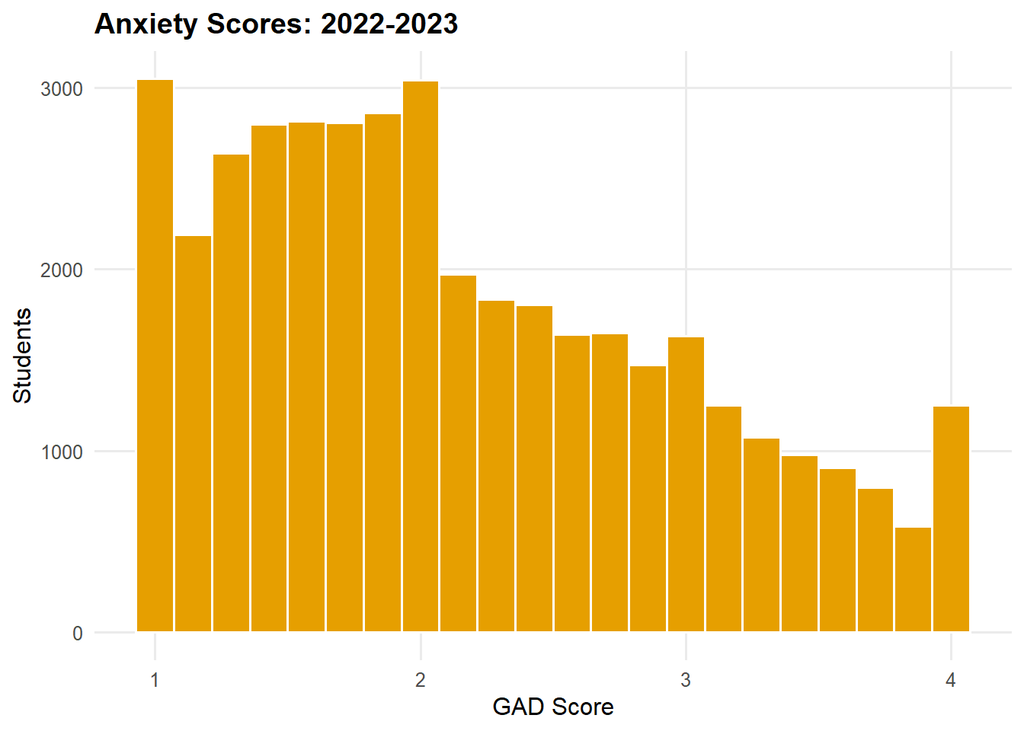

```r
# Plot the distribution of anxiety scores in the post-COVID sample.
ggplot(post_covid, aes(x = GAD)) +
  geom_histogram(
    binwidth = 1/7,
    fill = gad_color,
    color = "white"
  ) +
  labs(
    title = "Anxiety Scores: 2022-2023",
    x = "GAD Score",
    y = "Students"
  )
```

Anxiety scores were spread across the scale, with many students reporting lower to moderate levels of anxiety.

## 7.4 Gender Distribution

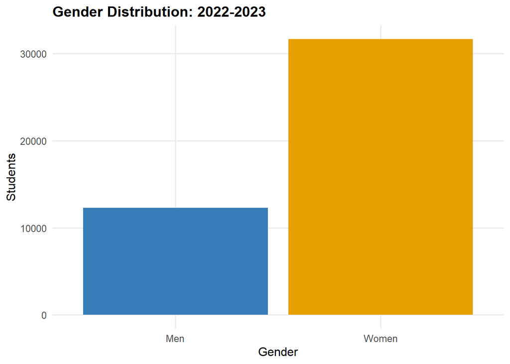

```r
# Show the gender composition of the post-COVID sample.
ggplot(
  filter(post_covid, !is.na(gender)),
  aes(x = gender, fill = gender)
) +
  geom_bar() +
  scale_fill_manual(values = gender_colors) +
  guides(fill = "none") +
  labs(
    title = "Gender Distribution: 2022-2023",
    x = "Gender",
    y = "Students"
  )
```

There were more women than men in the post-COVID sample.

## 7.5 STEM and Non-STEM Distribution

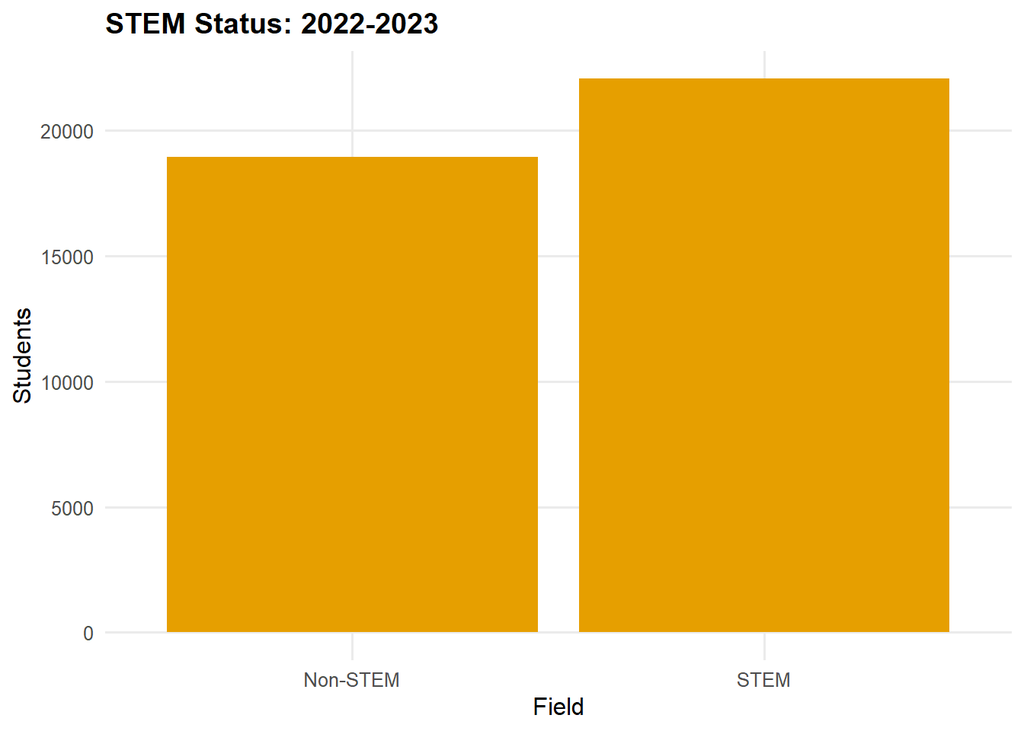

```r
# Show the distribution of STEM and non-STEM fields after COVID-19.
ggplot(
  filter(post_covid, !is.na(field)),
  aes(x = field)
) +
  geom_bar(fill = post_color) +
  labs(
    title = "STEM Status: 2022-2023",
    x = "Field",
    y = "Students"
  )
```

## 7.6 Race Distribution

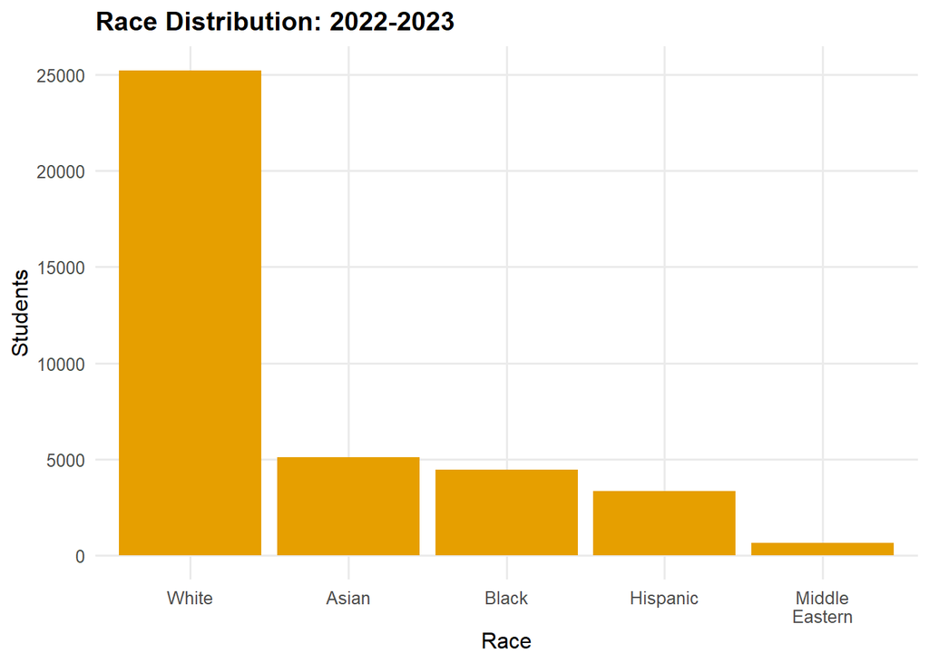

```r
# Describe the racial composition of the post-COVID sample.
ggplot(
  filter(post_covid, !is.na(race.2)),
  aes(x = race.2)
) +
  geom_bar(fill = post_color) +
  scale_x_discrete(
    labels = c(
      "White",
      "Asian",
      "Black",
      "Hispanic",
      "Middle\nEastern"
    )
  ) +
  labs(
    title = "Race Distribution: 2022-2023",
    x = "Race",
    y = "Students"
  )
```

White students made up the largest racial group in the post-COVID sample.

## 7.7 Year in School Distribution

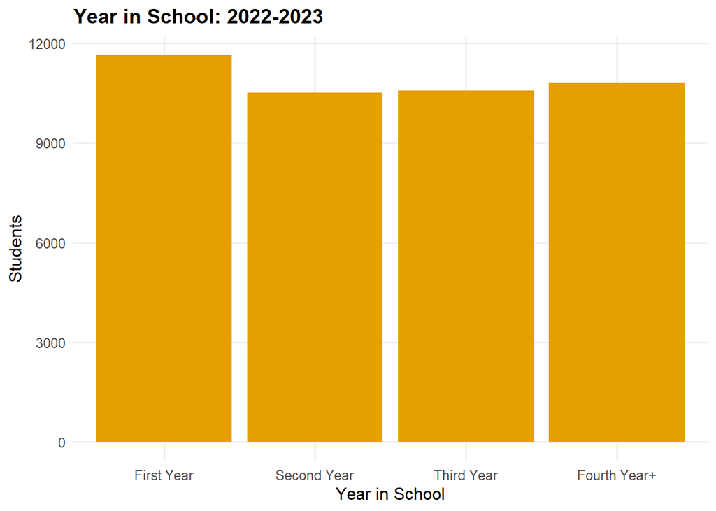

```r
# Show the distribution of students by year in school after COVID-19.
ggplot(
  filter(post_covid, !is.na(yr_sch.2)),
  aes(x = yr_sch.2)
) +
  geom_bar(fill = post_color) +
  scale_x_discrete(
    labels = c(
      "First Year",
      "Second Year",
      "Third Year",
      "Fourth Year+"
    )
  ) +
  labs(
    title = "Year in School: 2022-2023",
    x = "Year in School",
    y = "Students"
  )
```

Students from all years in school were represented in the post-COVID sample.

## 7.8 Financial Stress Distribution

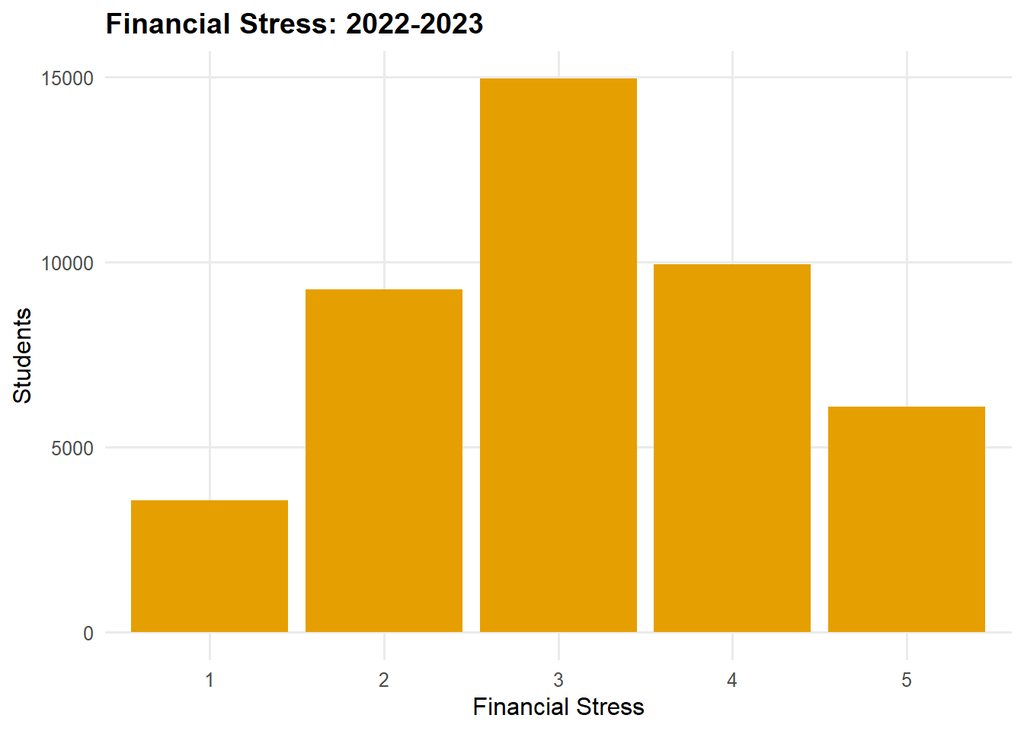

```r
# Describe current financial circumstances among post-COVID respondents.
ggplot(
  filter(post_covid, !is.na(fincur.2)),
  aes(x = factor(fincur.2))
) +
  geom_bar(fill = post_color) +
  labs(
    title = "Financial Stress: 2022-2023",
    x = "Financial Stress",
    y = "Students"
  )
```

Financial stress varied across students, with many students reporting moderate levels of financial stress.

## 7.9 Age Distribution

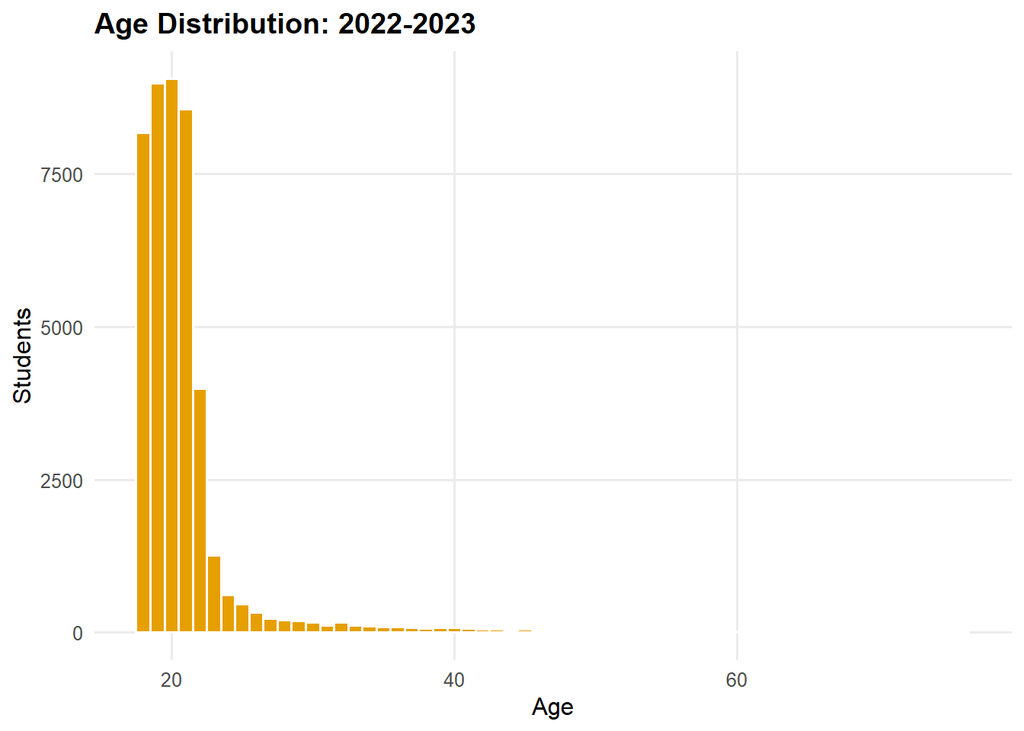

```r
# Plot the age distribution of students in the post-COVID sample.
ggplot(
  filter(post_covid, !is.na(age)),
  aes(x = age)
) +
  geom_histogram(
    binwidth = 1,
    fill = post_color,
    color = "white"
  ) +
  labs(
    title = "Age Distribution: 2022-2023",
    x = "Age",
    y = "Students"
  )
```

Most students were in the typical college-age range, with fewer students at older ages.

## 7.10 Mental Health by Gender

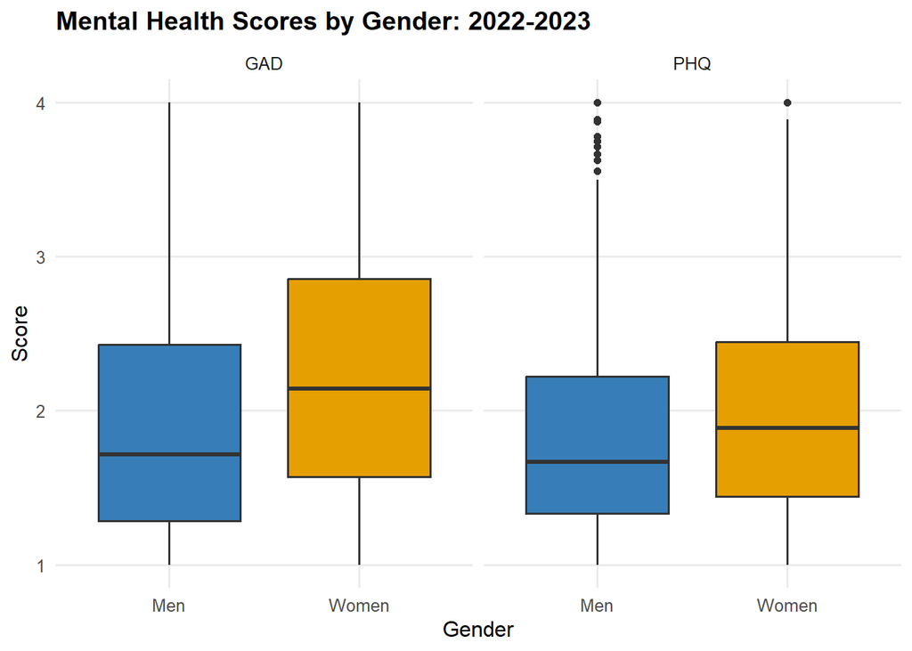

```r
# Compare post-COVID depression and anxiety scores across gender groups.
post_gender_scores <- post_covid %>%
  select(gender, PHQ, GAD) %>%
  pivot_longer(
    c(PHQ, GAD),
    names_to = "Measure",
    values_to = "Score"
  )

ggplot(
  filter(
    post_gender_scores,
    !is.na(gender),
    !is.na(Score)
  ),
  aes(
    x = gender,
    y = Score,
    fill = gender
  )
) +
  geom_boxplot() +
  facet_wrap(~Measure) +
  scale_fill_manual(values = gender_colors) +
  guides(fill = "none") +
  labs(
    title = "Mental Health Scores by Gender: 2022-2023",
    x = "Gender",
    y = "Score"
  )
```

Women generally had higher depression and anxiety scores than men after COVID.

## 7.11 Mental Health by STEM Status

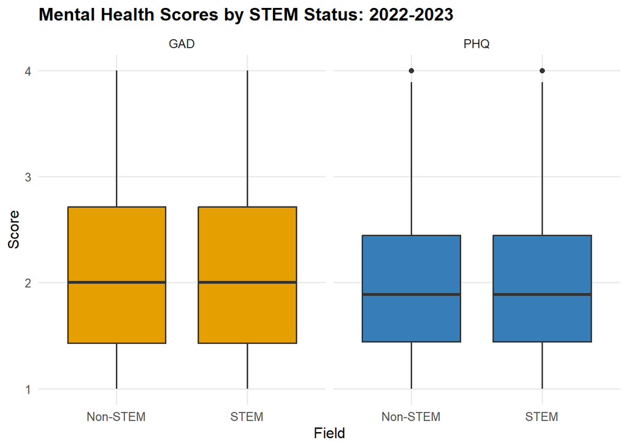

```r
# Compare post-COVID depression and anxiety scores by STEM field status.
post_field_scores <- post_covid %>%
  select(field, PHQ, GAD) %>%
  pivot_longer(
    c(PHQ, GAD),
    names_to = "Measure",
    values_to = "Score"
  )

ggplot(
  filter(
    post_field_scores,
    !is.na(field),
    !is.na(Score)
  ),
  aes(
    x = field,
    y = Score,
    fill = Measure
  )
) +
  geom_boxplot() +
  facet_wrap(~Measure) +
  scale_fill_manual(values = measure_colors) +
  guides(fill = "none") +
  labs(
    title = "Mental Health Scores by STEM Status: 2022-2023",
    x = "Field",
    y = "Score"
  )
```

## 7.12 Mental Health by Financial Stress

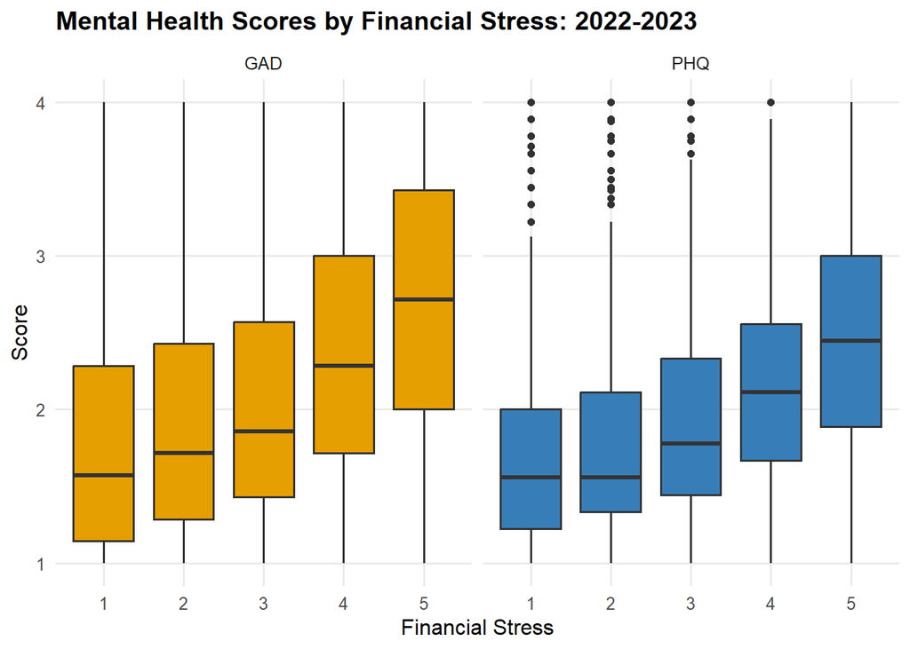

```r
# Examine post-COVID mental health scores across financial circumstances.
post_financial_scores <- post_covid %>%
  select(fincur.2, PHQ, GAD) %>%
  pivot_longer(
    c(PHQ, GAD),
    names_to = "Measure",
    values_to = "Score"
  )

ggplot(
  filter(
    post_financial_scores,
    !is.na(fincur.2),
    !is.na(Score)
  ),
  aes(
    x = factor(fincur.2),
    y = Score,
    fill = Measure
  )
) +
  geom_boxplot() +
  facet_wrap(~Measure) +
  scale_fill_manual(values = measure_colors) +
  guides(fill = "none") +
  labs(
    title = "Mental Health Scores by Financial Stress: 2022-2023",
    x = "Financial Stress",
    y = "Score"
  )
```

## 7.13 Mental Health by Race

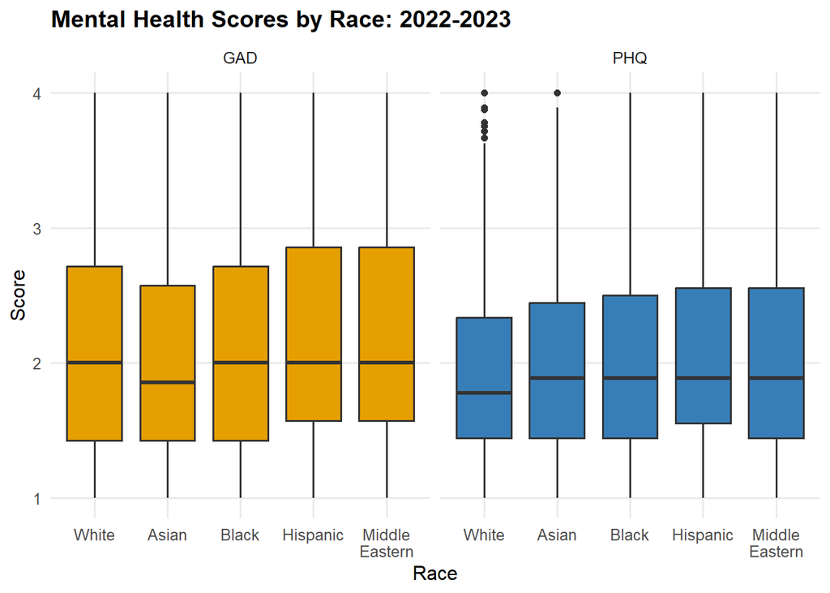

```r
# Compare post-COVID depression and anxiety scores across racial groups.
post_race_scores <- post_covid %>%
  select(race.2, PHQ, GAD) %>%
  pivot_longer(
    c(PHQ, GAD),
    names_to = "Measure",
    values_to = "Score"
  )

ggplot(
  filter(
    post_race_scores,
    !is.na(race.2),
    !is.na(Score)
  ),
  aes(
    x = race.2,
    y = Score,
    fill = Measure
  )
) +
  geom_boxplot() +
  facet_wrap(~Measure) +
  scale_fill_manual(values = measure_colors) +
  guides(fill = "none") +
  scale_x_discrete(
    labels = c(
      "White",
      "Asian",
      "Black",
      "Hispanic",
      "Middle\nEastern"
    )
  ) +
  labs(
    title = "Mental Health Scores by Race: 2022-2023",
    x = "Race",
    y = "Score"
  )
```

Depression and anxiety scores varied somewhat across racial groups after COVID.

## 7.14 Mental Health by Year in School

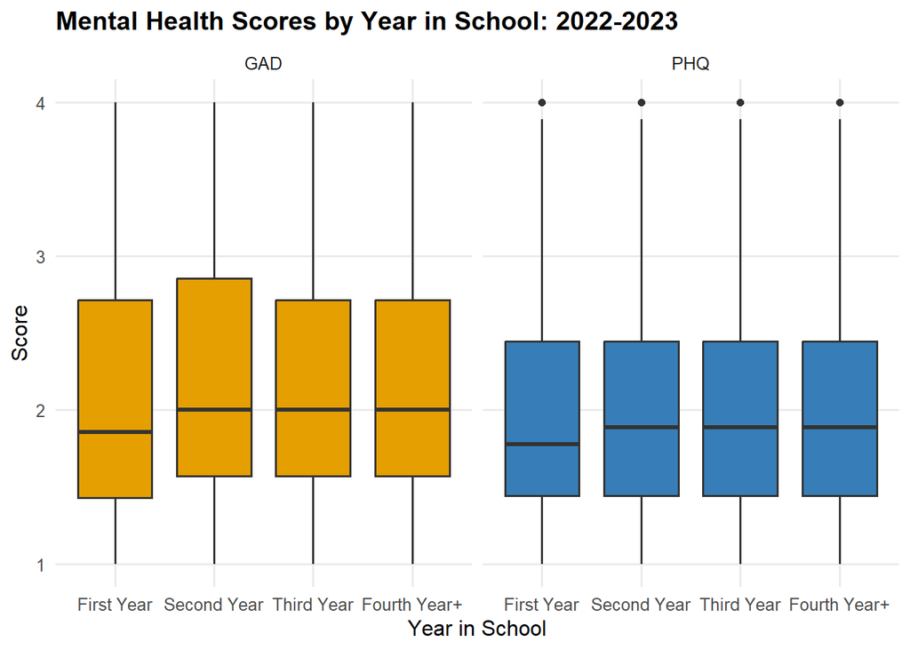

```r
# Compare post-COVID depression and anxiety scores by year in school.
post_year_scores <- post_covid %>%
  select(yr_sch.2, PHQ, GAD) %>%
  pivot_longer(
    c(PHQ, GAD),
    names_to = "Measure",
    values_to = "Score"
  )

ggplot(
  filter(
    post_year_scores,
    !is.na(yr_sch.2),
    !is.na(Score)
  ),
  aes(
    x = yr_sch.2,
    y = Score,
    fill = Measure
  )
) +
  geom_boxplot() +
  facet_wrap(~Measure) +
  scale_fill_manual(values = measure_colors) +
  guides(fill = "none") +
  scale_x_discrete(
    labels = c(
      "First Year",
      "Second Year",
      "Third Year",
      "Fourth Year+"
    )
  ) +
  labs(
    title = "Mental Health Scores by Year in School: 2022-2023",
    x = "Year in School",
    y = "Score"
  )
```

## 7.15 Depression and Anxiety Relationship

```r
# Calculate the correlation between post-COVID depression and anxiety scores.
post_correlation <- cor(
  post_covid$PHQ,
  post_covid$GAD,
  use = "complete.obs"
)

post_correlation
```

```
## [1] 0.7419098
```

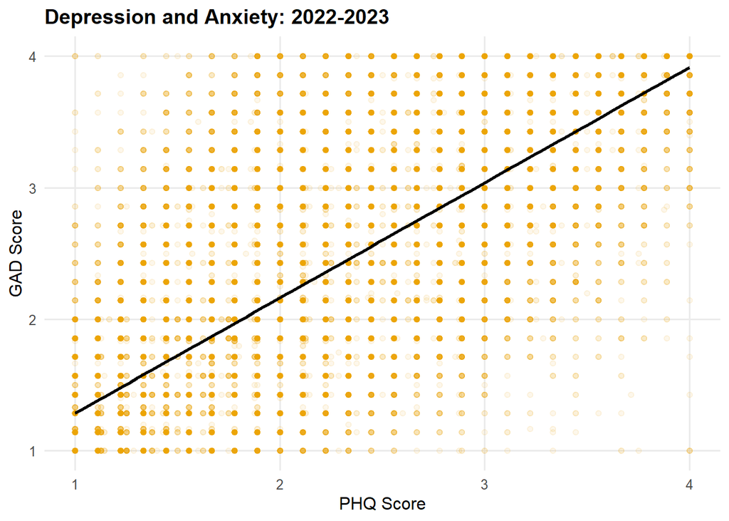

```r
# Visualize the relationship between post-COVID depression and anxiety scores.
ggplot(
  post_covid,
  aes(x = PHQ, y = GAD)
) +
  geom_point(
    alpha = 0.08,
    color = post_color
  ) +
  geom_smooth(
    method = "lm",
    se = FALSE,
    color = "black"
  ) +
  labs(
    title = "Depression and Anxiety: 2022-2023",
    x = "PHQ Score",
    y = "GAD Score"
  )
```

Depression and anxiety had a strong positive relationship after COVID, so students with higher depression scores also tended to have higher anxiety scores.

# 8 Pre-COVID vs. Post-COVID Comparison

## 8.1 Create Combined Dataset

```r
# Combine the two samples and label each observation by COVID period.
pre_compare <- pre_covid %>%
  select(all_of(variables_used)) %>%
  mutate(
    Period = "2017-2018 Pre-COVID"
  )

post_compare <- post_covid %>%
  select(all_of(variables_used)) %>%
  mutate(
    Period = "2022-2023 Post-COVID"
  )

combined <- bind_rows(
  pre_compare,
  post_compare
)

combined$Period <- factor(
  combined$Period,
  levels = c(
    "2017-2018 Pre-COVID",
    "2022-2023 Post-COVID"
  )
)
```

## 8.2 Sample Sizes

```r
# Compare the total sample sizes for the pre-COVID and post-COVID periods.
combined %>%
  count(Period) %>%
  knitr::kable(
    caption = "Sample Size by Time Period"
  )
```

Sample Size by Time Period

| Period | n |
| --- | --- |
| 2017-2018 Pre-COVID | 68427 |
| 2022-2023 Post-COVID | 43910 |

## 8.3 Missing Data Comparison

```r
# Compare missing-data patterns across the two COVID periods.
missing_comparison <- combined %>%
  group_by(Period) %>%
  summarise(
    PHQ = mean(is.na(PHQ)) * 100,
    GAD = mean(is.na(GAD)) * 100,
    Gender = mean(is.na(gender)) * 100,
    Field = mean(is.na(field)) * 100,
    Race = mean(is.na(race.2)) * 100,
    Year = mean(is.na(yr_sch.2)) * 100,
    Financial_Stress = mean(is.na(fincur.2)) * 100,
    Age = mean(is.na(age)) * 100
  ) %>%
  mutate(
    across(
      where(is.numeric),
      ~ round(., 2)
    )
  )

knitr::kable(
  missing_comparison,
  caption = "Percent Missing by Time Period"
)
```

Percent Missing by Time Period

| Period | PHQ | GAD | Gender | Field | Race | Year | Financial_Stress | Age |
| --- | --- | --- | --- | --- | --- | --- | --- | --- |
| 2017-2018 Pre-COVID | 24.53 | 25.37 | 2.74 | 16.30 | 12.35 | 8.76 | 1.44 | 0 |
| 2022-2023 Post-COVID | 5.56 | 6.52 | 0.00 | 6.58 | 11.73 | 0.95 | 0.10 | 0 |

## 8.4 Demographic Comparison

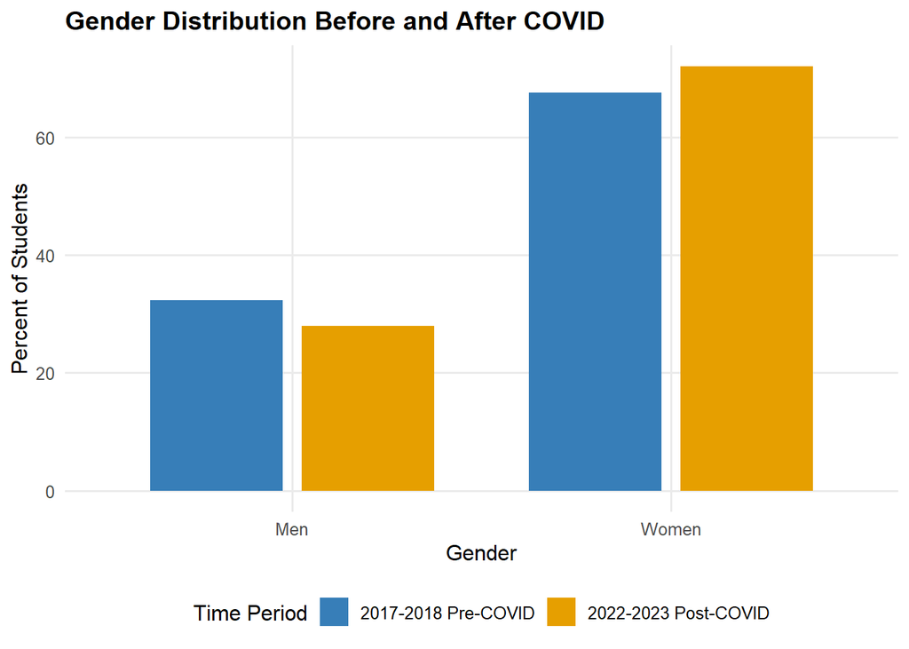

```r
# Compare gender distributions between the pre-COVID and post-COVID samples.
gender_comparison <- combined %>%
  filter(!is.na(gender)) %>%
  count(Period, gender) %>%
  group_by(Period) %>%
  mutate(
    Percent = n / sum(n) * 100
  )

ggplot(
  gender_comparison,
  aes(
    x = gender,
    y = Percent,
    fill = Period
  )
) +
  geom_col(
    position = position_dodge(width = 0.8),
    width = 0.7
  ) +
  scale_fill_manual(values = period_colors) +
  labs(
    title = "Gender Distribution Before and After COVID",
    x = "Gender",
    y = "Percent of Students",
    fill = "Time Period"
  )
```

The gender makeup was somewhat different between the two time periods, showing why gender should be considered when comparing mental health outcomes.

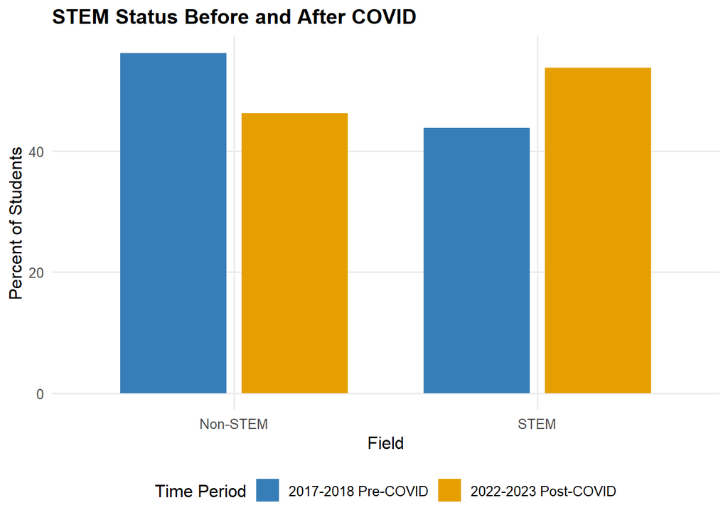

```r
# Compare STEM and non-STEM representation across COVID periods.
field_comparison <- combined %>%
  filter(!is.na(field)) %>%
  count(Period, field) %>%
  group_by(Period) %>%
  mutate(
    Percent = n / sum(n) * 100
  )

ggplot(
  field_comparison,
  aes(
    x = field,
    y = Percent,
    fill = Period
  )
) +
  geom_col(
    position = position_dodge(width = 0.8),
    width = 0.7
  ) +
  scale_fill_manual(values = period_colors) +
  labs(
    title = "STEM Status Before and After COVID",
    x = "Field",
    y = "Percent of Students",
    fill = "Time Period"
  )
```

The proportion of STEM and non-STEM students differed somewhat between the pre-COVID and post-COVID samples.

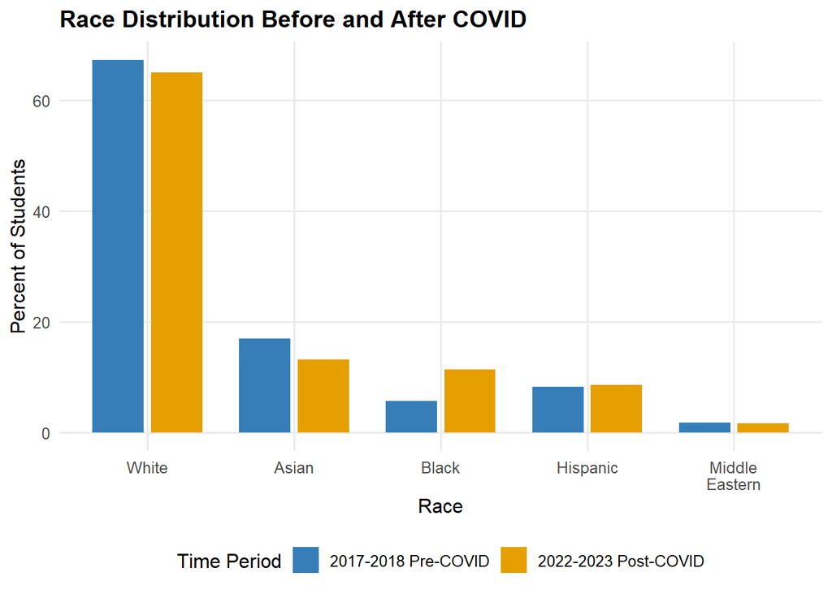

```r
# Compare racial composition across the pre-COVID and post-COVID samples.
race_comparison <- combined %>%
  filter(!is.na(race.2)) %>%
  count(Period, race.2) %>%
  group_by(Period) %>%
  mutate(
    Percent = n / sum(n) * 100
  )

ggplot(
  race_comparison,
  aes(
    x = race.2,
    y = Percent,
    fill = Period
  )
) +
  geom_col(
    position = position_dodge(width = 0.8),
    width = 0.7
  ) +
  scale_fill_manual(values = period_colors) +
  scale_x_discrete(
    labels = c(
      "White",
      "Asian",
      "Black",
      "Hispanic",
      "Middle\nEastern"
    )
  ) +
  labs(
    title = "Race Distribution Before and After COVID",
    x = "Race",
    y = "Percent of Students",
    fill = "Time Period"
  )
```

The racial makeup of the samples differed somewhat between the two time periods, which is important to consider when comparing them.

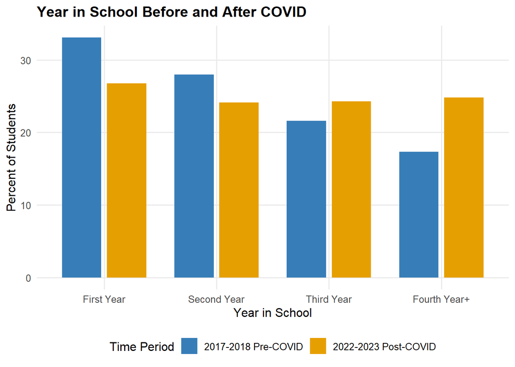

```r
# Compare year-in-school distributions across the two periods.
year_comparison <- combined %>%
  filter(!is.na(yr_sch.2)) %>%
  count(Period, yr_sch.2) %>%
  group_by(Period) %>%
  mutate(
    Percent = n / sum(n) * 100
  )

ggplot(
  year_comparison,
  aes(
    x = yr_sch.2,
    y = Percent,
    fill = Period
  )
) +
  geom_col(
    position = position_dodge(width = 0.8),
    width = 0.7
  ) +
  scale_fill_manual(values = period_colors) +
  scale_x_discrete(
    labels = c(
      "First Year",
      "Second Year",
      "Third Year",
      "Fourth Year+"
    )
  ) +
  labs(
    title = "Year in School Before and After COVID",
    x = "Year in School",
    y = "Percent of Students",
    fill = "Time Period"
  )
```

The distribution of students across years in school was somewhat different between the pre-COVID and post-COVID samples.